# hw8_fissel

Morgan Fissel

3/25/2022

Question 2 a) full inde

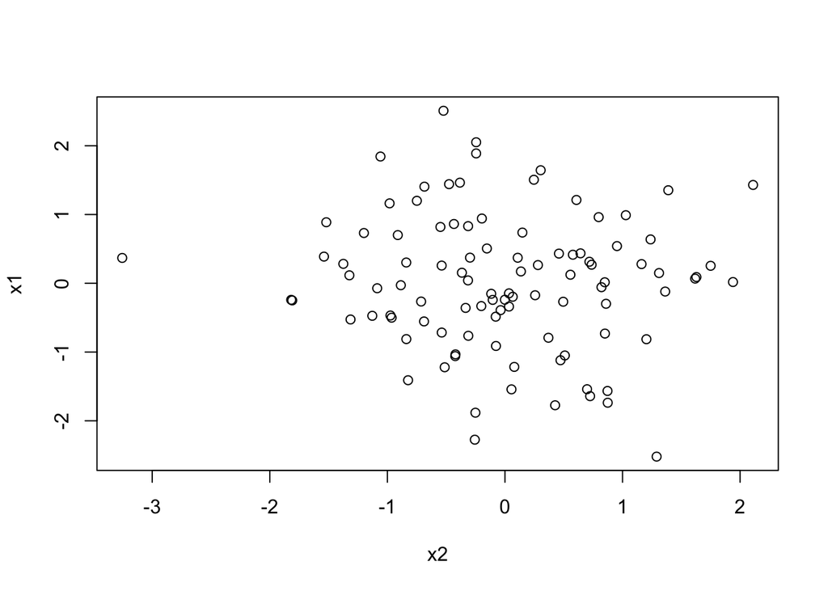

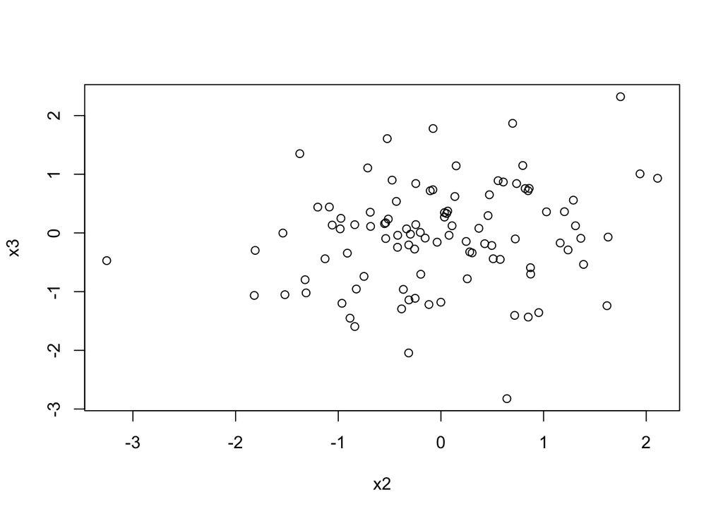

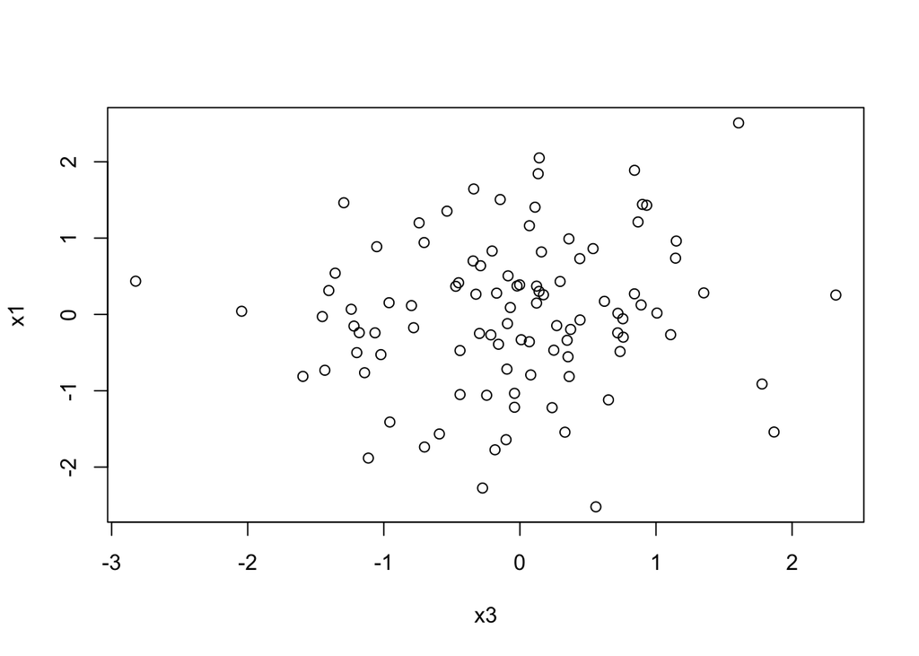

```r
inde_fun = function(n=100, mu1=0,sd1=1,a=0,b=0,c=0,d=0,e=0){

  x1 = rnorm(n, mean= mu1, sd = sd1)

  mu2 = a + b*x1 # b = x2Rx1
  sd2 = 1
  x2 = rnorm(n, mean= mu2, sd = sd2)

  mu3 = c + d*x1 + e*x2 #d = x1Rx3, e = x2Rx3
  sd3 = 1
  x3 = rnorm(n, mean= mu3, sd = sd3)

  plot(x1~x2)
  plot(x3~x2)
  plot(x1~x3)

}

inde_fun(n=100)
```

The general lack of overlapping points and seemingly random spread throughout the graphs, suggest to me that this is indeed full independence. b) partial inde

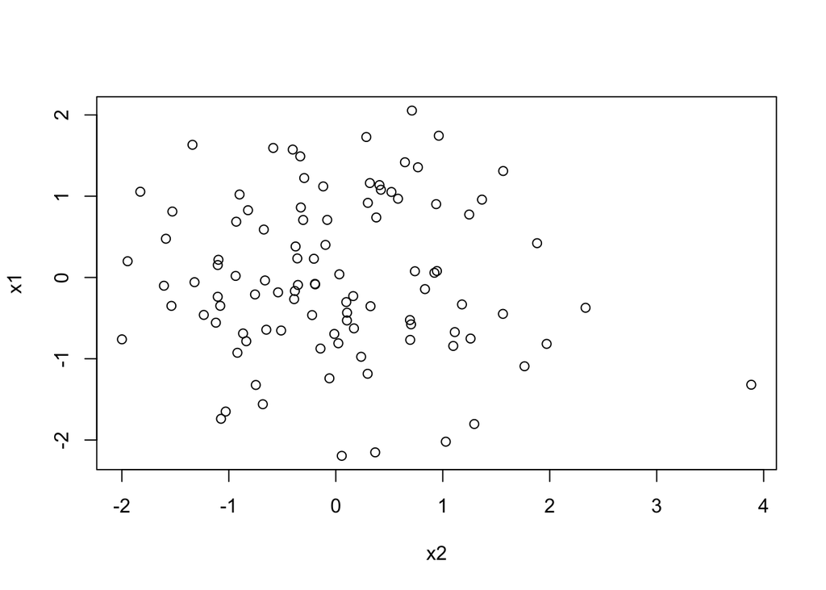

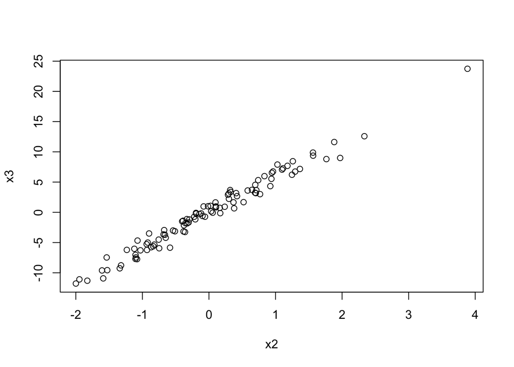

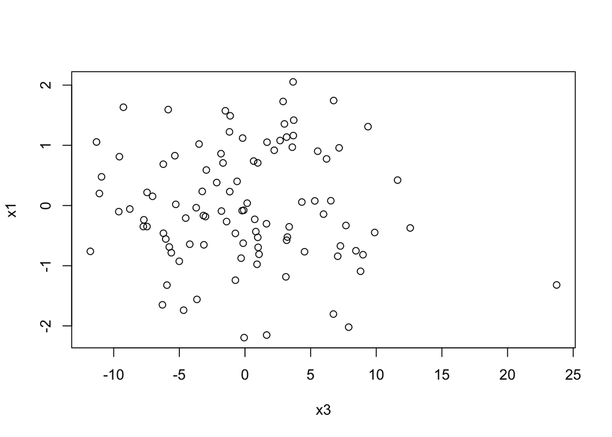

```r
inde_fun = function(n=100, mu1=0,sd1=1,a=0,b=0,c=0,d=0,e=0){

  x1 = rnorm(n, mean= mu1, sd = sd1)

  mu2 = a + b*x1 # b = x2Rx1
  sd2 = 1
  x2 = rnorm(n, mean= mu2, sd = sd2)

  mu3 = c + d*x1 + e*x2 #d = x1Rx3, e = x2Rx3
  sd3 = 1
  x3 = rnorm(n, mean= mu3, sd = sd3)

  plot(x1~x2)
  plot(x3~x2)
  plot(x1~x3)

}

inde_fun(n=100,e=6)
```

(x1 and x2) and (x1 and x3) seem to be independent, with random spreads and little overlap or direction however, x2 and x3 seem to be strongly correlated, with a positive relationship (slope). Many overlapping points, more like a line.

3. marginal inde

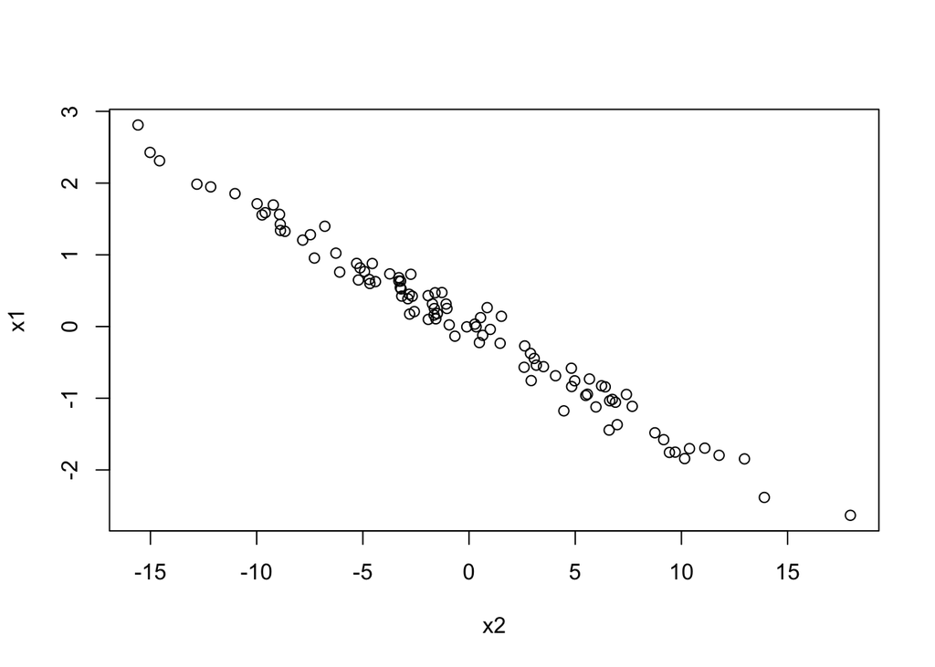

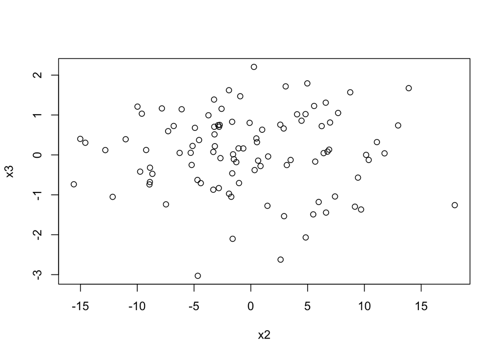

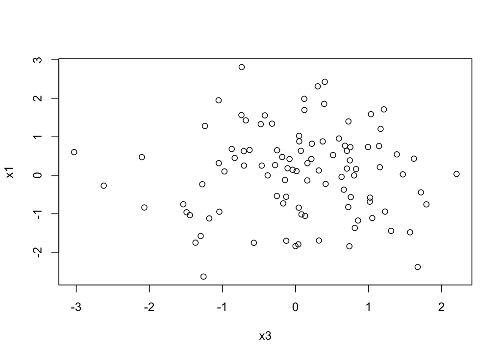

```r
inde_fun = function(n=100, mu1=0,sd1=1,a=0,b=0,c=0,d=0,e=0){

  x1 = rnorm(n, mean= mu1, sd = sd1)

  mu2 = a + b*x1 # b = x2Rx1
  sd2 = 1
  x2 = rnorm(n, mean= mu2, sd = sd2)

  mu3 = c + d*x1 + e*x2 #d = x1Rx3, e = x2Rx3
  sd3 = 1
  x3 = rnorm(n, mean= mu3, sd = sd3)

  plot(x1~x2)
  plot(x3~x2)
  plot(x1~x3)

}

inde_fun(n=100,b=-6)
```

The first graph relates x1 and x2 and shows a negative slope, lots of dots overlapping and forming (almost) a line. This is different from the other two graphs which seems to be randomly placed dots spread not really overlapping, so it seems x2Rx1, but not(x1Rx3 or x2Rx3).

4. conditional inde

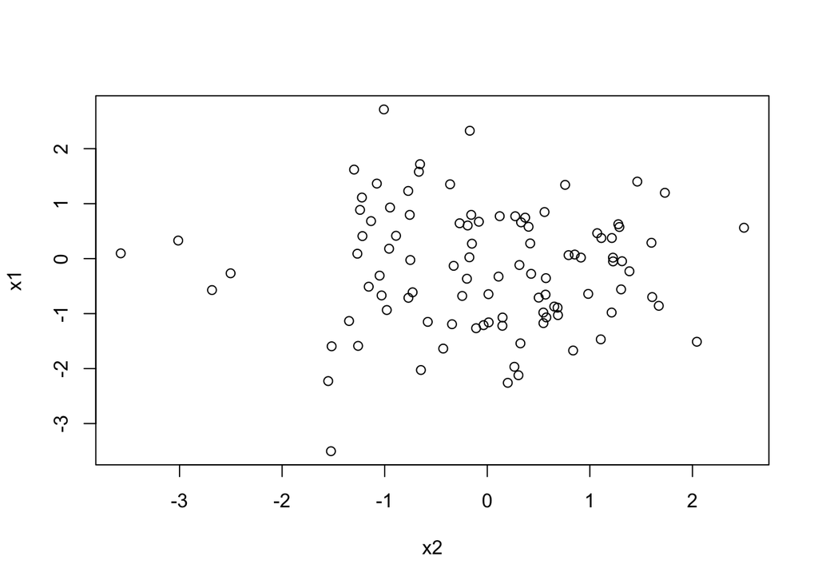

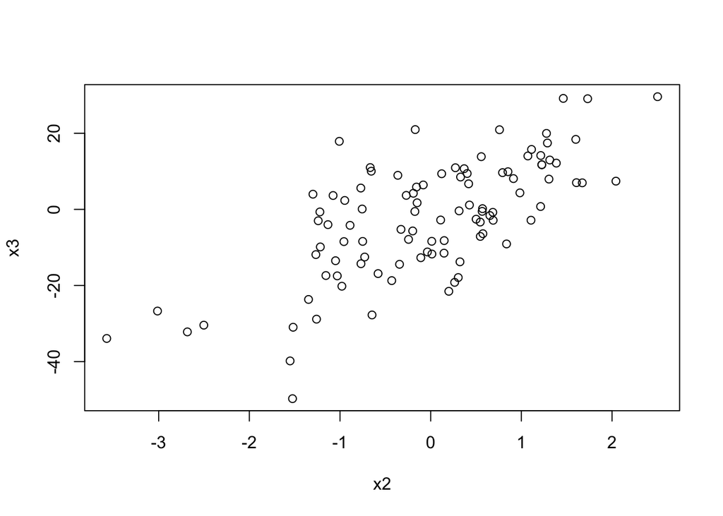

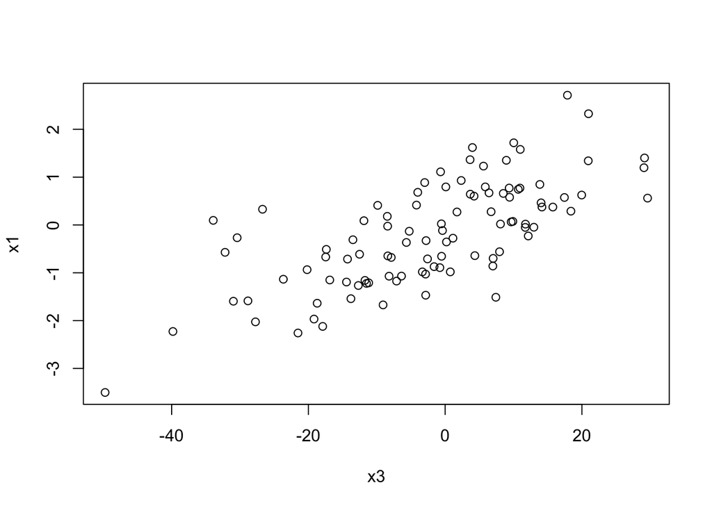

```r
inde_fun = function(n=100, mu1=0,sd1=1,a=0,b=0,c=0,d=0,e=0){

  x1 = rnorm(n, mean= mu1, sd = sd1)

  mu2 = a + b*x1 # b = x2Rx1
  sd2 = 1
  x2 = rnorm(n, mean= mu2, sd = sd2)

  mu3 = c + d*x1 + e*x2 #d = x1Rx3, e = x2Rx3
  sd3 = 1
  x3 = rnorm(n, mean= mu3, sd = sd3)

  plot(x1~x2)
  plot(x3~x2)
  plot(x1~x3)

}

inde_fun(n=100,d=10,e=10)
```

5. full dep

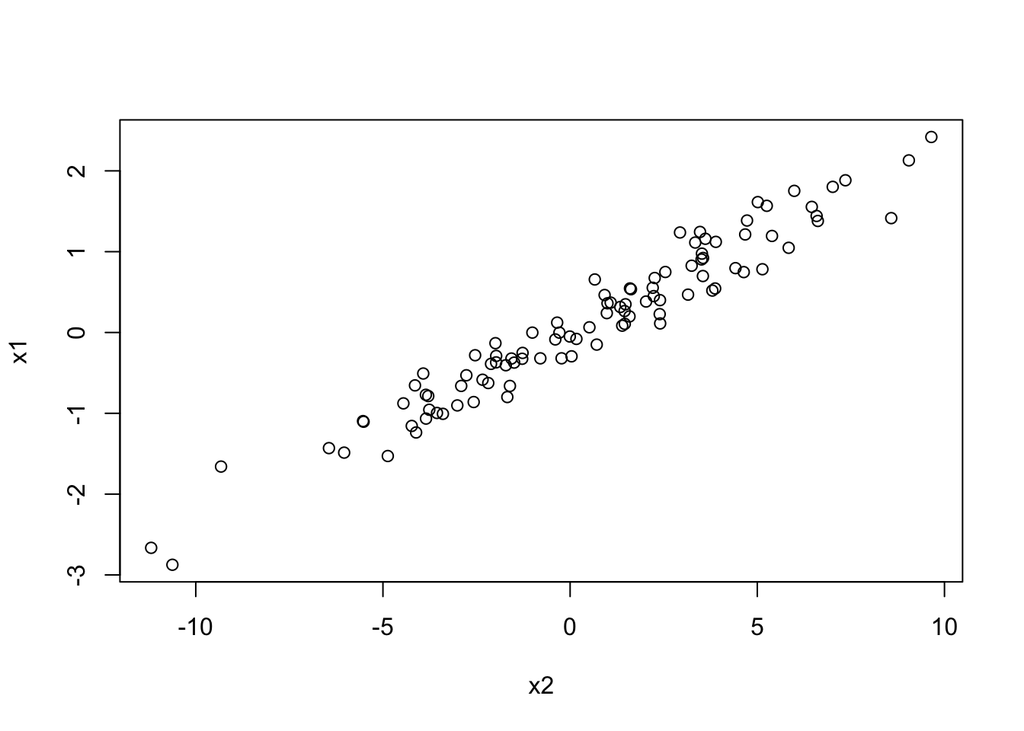

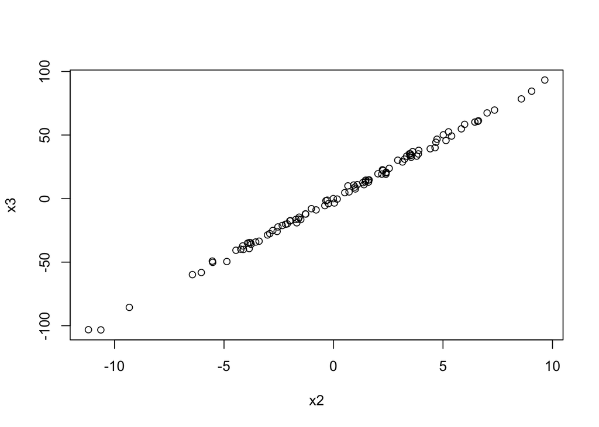

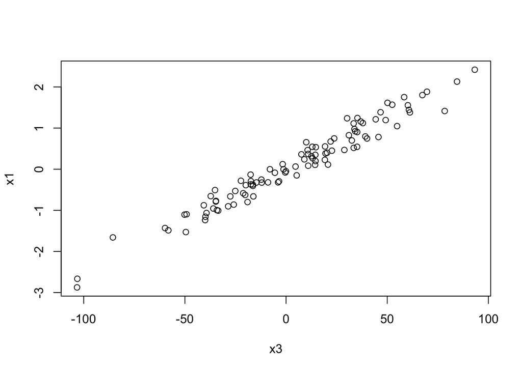

```r
inde_fun = function(n=100, mu1=0,sd1=1,a=0,b=0,c=0,d=0,e=0){

  x1 = rnorm(n, mean= mu1, sd = sd1)

  mu2 = a + b*x1 # b = x2Rx1
  sd2 = 1
  x2 = rnorm(n, mean= mu2, sd = sd2)

  mu3 = c + d*x1 + e*x2 #d = x1Rx3, e = x2Rx3
  sd3 = 1
  x3 = rnorm(n, mean= mu3, sd = sd3)

  plot(x1~x2)
  plot(x3~x2)
  plot(x1~x3)

}

inde_fun(n=100,b=4,d=6,e=8)
```

Full dependence! We can clearly tell all of the graphs, are positively sloped, and suggest a relation between each of the variables. The spread is tight and forms a line for all of our graphs here.